# GOV 1006 Problem Set #2

Maria Burzillo

2/10/2020

# **Question #1**

## a) Measures that have validity, but not reliability

An example of a measure that has a high level of validity but not of reliability would be a survey on a typical school night that asks students to report the number of hours of sleep they got the previous night to gauge how much sleep a Harvard student gets on average. In general, this would be a valid measuring process of the number of hours of sleep a student gets on a typical night; however, it would have low reliability because random factors such as who was up all night studying for a midterm and who simply couldn’t sleep the night before would affect the percision and stability of the measure if it was to be reproduced or if the same students were to be tested again.

## b) Measures that have reliability, but not validity

An example of a measure that has a high level of reliability but not validity would be a heart rate monitor at the MAC that is incorrectly calibrated so that it consistently reports an exerciser’s heart rate at 10 beats per minute above their actual heart rate. Because it’s measures of heart rate are precise and stable and reflect actual differences in the heart rate of different exercisers rather than measurement errors, the heart rate monitor is reliable. However, becuase it is not an accurate reflection of a person’s actual heartrate (being 10bpm off), it is therefore not valid.

## c) A Harvard Specific Policy: validity, reliability, and sample selection

I was once asked to fill out a survey regarding inclusivity in Harvard’s math department, specifically related to gender equality. The first potential issue with this survey was that it likely collected responses from a nonrepresentative sample of the Harvard population. For example, it likely garnered responses only from those who had strong opinions and were willing to take the time to fill out the survey, which would likely bias the results one way or the other.

In terms of validity, the survey was not likely highly valid because the questions it asked such as how many female professors a student had had at Harvard in the math department was not likely a very good measure of overall inclusivity. However, the survey was likely reliable because the differences in the responses would be due to real differences in survey respondents rather than errors from measurements.

# **Question #2**

## a)

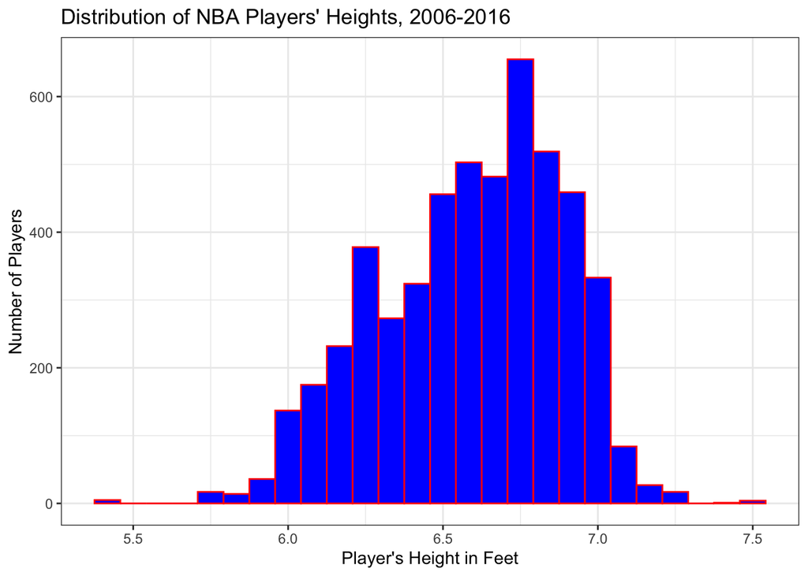

## b)

The mean of the distribution is 6.59 feet.

## c)

The variance of the distribution is the mean of the squarred difference from the mean. This essentially means that the variance represents the spread of the data from the mean. In our data set, the variance is very low at 0.087. Thus, there is a relatively low spread of the values, and most are clustered around the mean of 6.59 feet. It would probably be better to look at the spread of the data in terms of standard deviation, though, since it is often easier to interpret as it is on the original scale of the distribution.

# **Question #3**

[figure not shown]

[figure not shown]

[figure not shown]

By breaking down the time series data on Sudden Infant Death Syndrome (SIDS) death rates, it is interesting to see how the overall decline in the SIDS death rate is not distributed equally across various demographics. For example, declines among the African American population have been much more significant than declines for either Asian or Pacific Islanders or Whites. Nevertheless, the larger decline in death rates for African Americans has not led to the elimination of racial disparities in death rates by any means. In terms of regional trends, all regions appear to have experienced declines in the SIDS death rates. Rates have declined the most in the South and the Midwest, where they were highest to begin with.

# Collaborators:

Feven and Cris